# PML Course project

# Prediction of correctness of barbell lifting

### Background

Using devices such as Jawbone Up, Nike FuelBand, and Fitbit it is now possible to collect a large amount of data about personal activity relatively inexpensively. One thing that people regularly do is quantify how much of a particular activity they do, but they rarely quantify how well they do it. In this project, we will use data from accelerometers on the belt, forearm, arm, and dumbell of 6 participants. They were asked to perform barbell lifts correctly and incorrectly in 5 different ways. More information is available from the website here: http://groupware.les.inf.puc-rio.br/har (see the section on the Weight Lifting Exercise Dataset).

### Donwloading and preparing data.

```r
# Here we download and load data

if (!file.exists("data/pml-training.csv")){
    download.file("https://d396qusza40orc.cloudfront.net/predmachlearn/pml-training.csv",destfile = "data/pml-training.csv")

}
if (!file.exists("data/pml-testing.csv")){
    download.file("https://d396qusza40orc.cloudfront.net/predmachlearn/pml-testing.csv",destfile = "data/pml-testing.csv")

}

pml_train = read.csv("data/pml-training.csv", header = TRUE)
pml_test = read.csv("data/pml-testing.csv", header = TRUE)

# summary(pml_train)

# There is some '#DIV/0!'. Thats why some numeric variables were incorrectly encoded as charaters. Below we correct them:

# cat("Train. Converted to numeric:")
for (each in colnames(pml_train)) {
    curr_var = pml_train[,each]
    if (is.character(curr_var) & any(grepl('#DIV/0!',curr_var, fixed=TRUE))) {
#         cat (each," ")
        pml_train[,each] = suppressWarnings(as.numeric(curr_var))
    }
}
```

From summary we can see that there is a lot of NA’s in data. Let’s quick summarize this NA’s in percents of observations. Also we summarize number of unique values in each column. We don’t need constants as predictors.

```r
    na_s = sapply(pml_train,function(each){ sum(is.na(each))})
    uniqs = sapply(pml_train,function(each){ length(unique(each))})
    data.frame('NAs, %' = na_s/nrow(pml_train)*100, Uniqs = uniqs)
```

```
##                          NAs... Uniqs
## X                          0.00 19622
## user_name                  0.00     6
## raw_timestamp_part_1       0.00   837
## raw_timestamp_part_2       0.00 16783
## cvtd_timestamp             0.00    20
## new_window                 0.00     2
## num_window                 0.00   858
## roll_belt                  0.00  1330
## pitch_belt                 0.00  1840
## yaw_belt                   0.00  1957
## total_accel_belt           0.00    29
## kurtosis_roll_belt        97.98   396
## kurtosis_picth_belt       98.09   316
## kurtosis_yaw_belt        100.00     1
## skewness_roll_belt        97.98   394
## skewness_roll_belt.1      98.09   337
## skewness_yaw_belt        100.00     1
## max_roll_belt             97.93   196
## max_picth_belt            97.93    23
## max_yaw_belt              97.98    67
## min_roll_belt             97.93   185
## min_pitch_belt            97.93    17
## min_yaw_belt              97.98    67
## amplitude_roll_belt       97.93   149
## amplitude_pitch_belt      97.93    14
## amplitude_yaw_belt        97.98     2
## var_total_accel_belt      97.93    66
## avg_roll_belt             97.93   192
## stddev_roll_belt          97.93    70
## var_roll_belt             97.93    97
## avg_pitch_belt            97.93   215
## stddev_pitch_belt         97.93    44
## var_pitch_belt            97.93    64
## avg_yaw_belt              97.93   241
## stddev_yaw_belt           97.93    59
## var_yaw_belt              97.93   146
## gyros_belt_x               0.00   140
## gyros_belt_y               0.00    69
## gyros_belt_z               0.00   169
```

[output cut: 106 more lines]

```
## stddev_pitch_forearm      97.93   324
## var_pitch_forearm         97.93   325
## avg_yaw_forearm           97.93   325
## stddev_yaw_forearm        97.93   323
## var_yaw_forearm           97.93   323
## gyros_forearm_x            0.00   298
## gyros_forearm_y            0.00   741
## gyros_forearm_z            0.00   307
## accel_forearm_x            0.00   794
## accel_forearm_y            0.00  1003
## accel_forearm_z            0.00   580
## magnet_forearm_x           0.00  1524
## magnet_forearm_y           0.00  1872
## magnet_forearm_z           0.00  1683
## classe                     0.00     5
```

Further we drop columns with NA’s, id, timestamps and windows. As part of preprocessing we convert variables ‘classe’ and ‘user_name’ to factors. We keep user_name in model because there are persons with the same names in the test sample. One may suppose that exercises dependent on personality.

```r
    w = pml_train[,na_s<1][,-c(1,3:7)]
    w$classe = factor(w$classe)
    w$user_name = factor(w$user_name)
```

### Modelling

We have multicategorial dependent variable so we will use Random Forest classifier. It’s work with nominal dependent variables and generally performs better than usual decision trees. We divide sample to training and testing samples in proportion 60/40.

```r
    library(caret)
    set.seed(20141123)
    inTrain = createDataPartition(w$classe, p = 0.6, list = FALSE)
    w_training = w[ inTrain,]
    w_testing = w[-inTrain,]
    res_train = train(classe ~.,data=w_training,trControl = trainControl(method="oob"), method = "rf")
    # prediction on training sample
    pr_train = predict(res_train,newdata=w_training)
    # prediction on testing sample
    pr_test = predict(res_train,newdata = w_testing)
    confusionMatrix(pr_train,w_training$classe) # errors on training sample
```

```
## Confusion Matrix and Statistics
##
##           Reference
## Prediction    A    B    C    D    E
##          A 3348    0    0    0    0
##          B    0 2279    0    0    0
##          C    0    0 2054    0    0
##          D    0    0    0 1930    0
##          E    0    0    0    0 2165
##
## Overall Statistics
##
##                Accuracy : 1
##                  95% CI : (1, 1)
##     No Information Rate : 0.284
##     P-Value [Acc > NIR] : <2e-16
##
##                   Kappa : 1
##  Mcnemar's Test P-Value : NA
##
## Statistics by Class:
##
##                      Class: A Class: B Class: C Class: D Class: E
## Sensitivity             1.000    1.000    1.000    1.000    1.000
## Specificity             1.000    1.000    1.000    1.000    1.000
## Pos Pred Value          1.000    1.000    1.000    1.000    1.000
## Neg Pred Value          1.000    1.000    1.000    1.000    1.000
## Prevalence              0.284    0.194    0.174    0.164    0.184
## Detection Rate          0.284    0.194    0.174    0.164    0.184
## Detection Prevalence    0.284    0.194    0.174    0.164    0.184
## Balanced Accuracy       1.000    1.000    1.000    1.000    1.000
```

```r
    confusionMatrix(pr_test,w_testing$classe) # errors on testing sample
```

```
## Confusion Matrix and Statistics
##
##           Reference
## Prediction    A    B    C    D    E
##          A 2231    9    0    0    0
##          B    1 1490    7    0    0
##          C    0   14 1355   12    2
##          D    0    3    6 1271    6
##          E    0    2    0    3 1434
##
## Overall Statistics
##
##                Accuracy : 0.992
##                  95% CI : (0.989, 0.994)
##     No Information Rate : 0.284
##     P-Value [Acc > NIR] : <2e-16
##
##                   Kappa : 0.99
##  Mcnemar's Test P-Value : NA
##
## Statistics by Class:
##
##                      Class: A Class: B Class: C Class: D Class: E
## Sensitivity             1.000    0.982    0.990    0.988    0.994
## Specificity             0.998    0.999    0.996    0.998    0.999
## Pos Pred Value          0.996    0.995    0.980    0.988    0.997
## Neg Pred Value          1.000    0.996    0.998    0.998    0.999
## Prevalence              0.284    0.193    0.174    0.164    0.184
## Detection Rate          0.284    0.190    0.173    0.162    0.183
## Detection Prevalence    0.285    0.191    0.176    0.164    0.183
## Balanced Accuracy       0.999    0.990    0.993    0.993    0.997
```

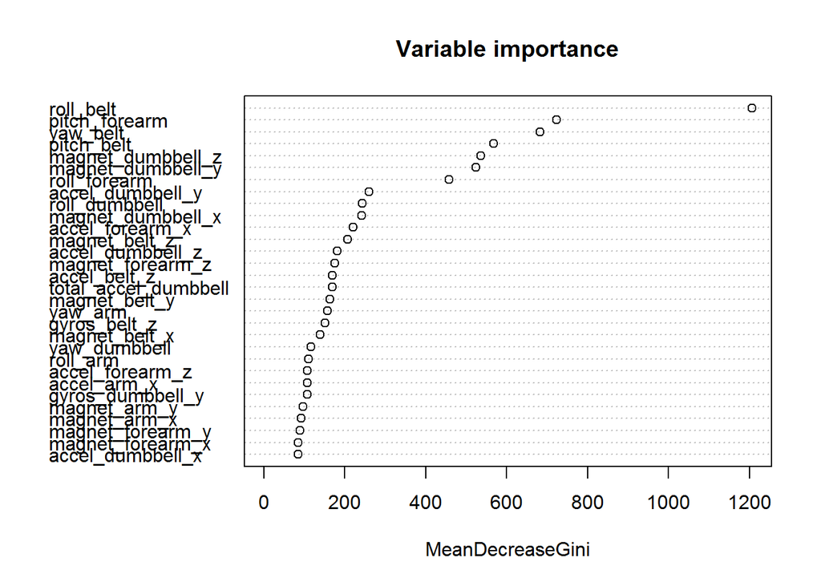

```r
    varImpPlot (res_train$finalModel,main="Variable importance")
```

So we can see 100% accuracy on training sample - it is obvious overfitting. But on testing sample we have 99% accuracy (out of sample error ~ 1%). I consider it as very good result.

### Prediction for assignment

We predict classe for file pml_test.csv and save results in separate files folder “Results”.

```r
answers = as.character(predict(res_train,newdata = pml_test))

pml_write_files = function(x){
  n = length(x)
  for(i in 1:n){
    filename = paste0("results/problem_id_",i,".txt")
    write.table(x[i],file=filename,quote=FALSE,row.names=FALSE,col.names=FALSE)
  }
}
pml_write_files(answers)
```

After submitting this results I have 1 error from 20 problems. Not perfect but acceptable.

**Thank you for you attention.**